# 03-BirdNET-Analysis

## Species Diversity

*Currently the species graphics are only for the first deployments of 2023. Running BirdNET requires a lot of time and processing power, so we have only completed one round of processing.Will need to update this if it is ever worth the effort*

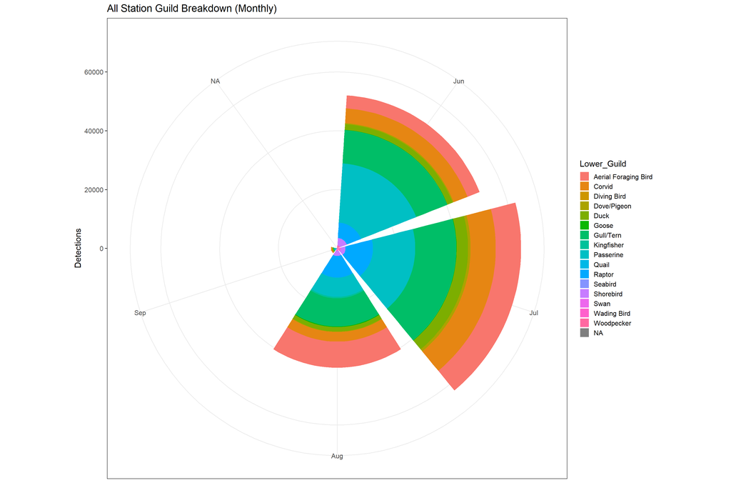

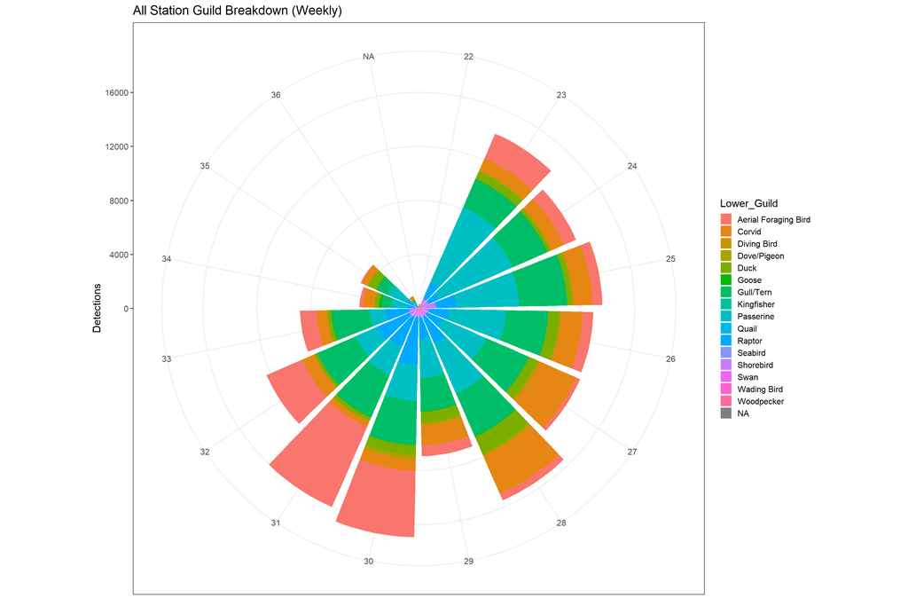

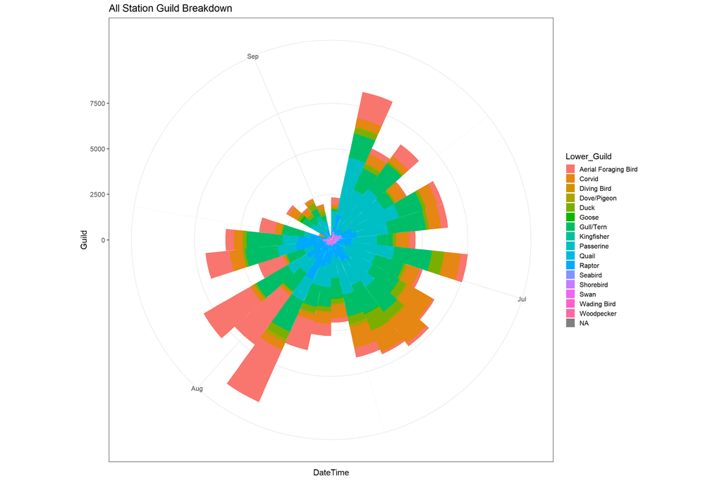

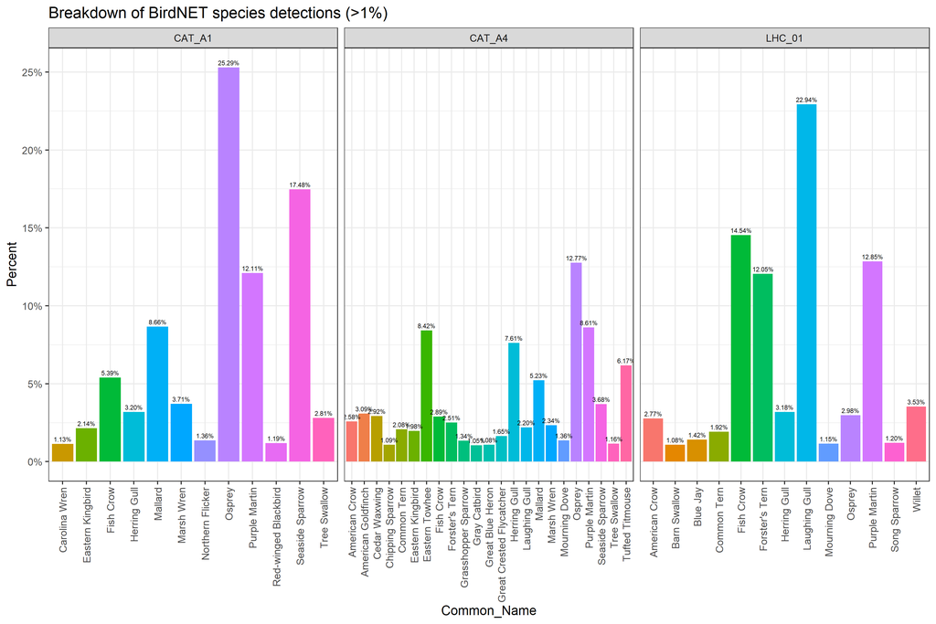

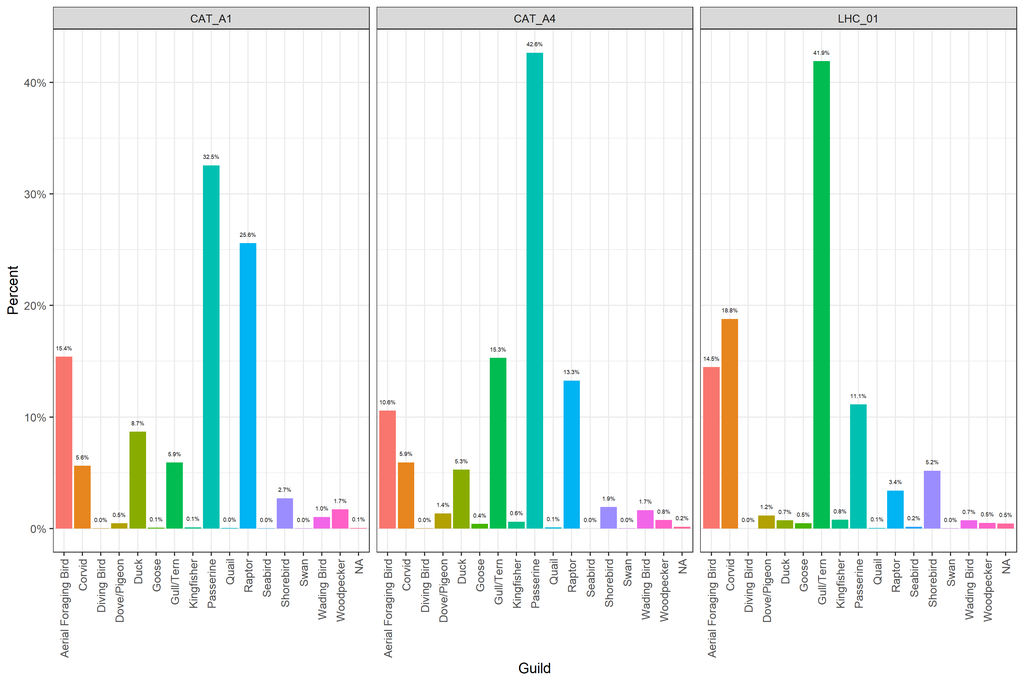

## Summary Tables

```r
st(species_data_birdnet %>% dplyr::select(c("Site", "Station", "Confidence", "Common_Birds")), group= 'Common_Birds', group.long = TRUE)
```

Summary Statistics

| Variable | N | Mean | Std. Dev. | Min | Pctl. 25 | Pctl. 75 | Max |
| --- | --- | --- | --- | --- | --- | --- | --- |
| Common_Birds: AHGU |  |  |  |  |  |  |  |
| Site | 6581 |  |  |  |  |  |  |
| … Cattus_Island | 4594 | 70% |  |  |  |  |  |
| … Lighthouse_Center | 1987 | 30% |  |  |  |  |  |
| Station | 6581 |  |  |  |  |  |  |
| … CAT_A1 | 1915 | 29% |  |  |  |  |  |
| … CAT_A4 | 2679 | 41% |  |  |  |  |  |
| … LHC_01 | 1987 | 30% |  |  |  |  |  |
| Confidence | 6581 | 0.49 | 0.17 | 0.25 | 0.34 | 0.6 | 0.97 |
| Common_Birds: BLJA |  |  |  |  |  |  |  |
| Site | 1056 |  |  |  |  |  |  |
| … Cattus_Island | 170 | 16% |  |  |  |  |  |
| … Lighthouse_Center | 886 | 84% |  |  |  |  |  |
| Station | 1056 |  |  |  |  |  |  |
| … CAT_A1 | 24 | 2% |  |  |  |  |  |
| … CAT_A4 | 146 | 14% |  |  |  |  |  |
| … LHC_01 | 886 | 84% |  |  |  |  |  |
| Confidence | 1056 | 0.5 | 0.21 | 0.25 | 0.32 | 0.67 | 0.99 |
| Common_Birds: CACH |  |  |  |  |  |  |  |
| Site | 132 |  |  |  |  |  |  |
| … Cattus_Island | 7 | 5% |  |  |  |  |  |
| … Lighthouse_Center | 125 | 95% |  |  |  |  |  |
| Station | 132 |  |  |  |  |  |  |
| … CAT_A1 | 0 | 0% |  |  |  |  |  |
| … CAT_A4 | 7 | 5% |  |  |  |  |  |
| … LHC_01 | 125 | 95% |  |  |  |  |  |
| Confidence | 132 | 0.47 | 0.19 | 0.25 | 0.31 | 0.59 | 0.93 |
| Common_Birds: CAGO |  |  |  |  |  |  |  |
| Site | 490 |  |  |  |  |  |  |
| … Cattus_Island | 186 | 38% |  |  |  |  |  |

[output cut: 231 more lines]

```r
st(species_breakdown)
```

Summary Statistics

| Variable | N | Mean | Std. Dev. | Min | Pctl. 25 | Pctl. 75 | Max |
| --- | --- | --- | --- | --- | --- | --- | --- |
| Station | 383 |  |  |  |  |  |  |
| … CAT_A1 | 129 | 34% |  |  |  |  |  |
| … CAT_A4 | 126 | 33% |  |  |  |  |  |
| … LHC_01 | 128 | 33% |  |  |  |  |  |
| Count | 383 | 412 | 1517 | 1 | 8 | 188 | 15157 |
| Percent | 383 | 0.78 | 2.6 | 0 | 0.02 | 0.4 | 25 |

## Community Ecology Approach

Using vegan package, etc. Add more info here later as this evolves.

```r
# Build a matrix of species detections to run future code on. This is not filtering any detections. It may be worth including a section above on post-processing for false positives and negatives. Currently, (1/6/26) this code is just the raw results. Change this note when that updates.

file_species <- species_data_birdnet %>%
  filter(!is.na(Scientific_Name)) %>%
  group_by(File_Name, Station, Common_Name) %>%
  summarise(
    detections = n(),
    .groups = "drop"
  )

comm_abund <- file_species %>%
  pivot_wider(names_from = Common_Name,
              values_from = detections,
              values_fill = 0)

comm_matrix <- comm_abund %>%
  dplyr::select(-Station, -File_Name)

comm_pa <- comm_matrix
comm_pa[comm_pa > 0] <- 1 #creates a presence/ absence matrix rather than the number of detections. Avoids calling rate bias.

# Next, as a temporary solution for a lack of post-processing procedure, this code will filter some of the matrix data to get rid of some species that are likely true false positives since they occur in less than 3 files. To be considered "present" in this matrix, you have to be at this site for more than 3 files (which are 15 min recordings).In this case, it got rid of 7 species.

species_site_occ <- file_species %>%
  group_by(Station, Common_Name) %>%
  summarise(n_files = n_distinct(File_Name), .groups = "drop")

valid_species <- species_site_occ %>%
  filter(n_files >= 3) %>%
  pull(Common_Name)

comm_pa_filt <- comm_pa[, colnames(comm_pa) %in% valid_species]
```

Because BirdNET confidence scores are not calibrated probabilities of correct classification and may not reliably reflect species-level accuracy, the results below currently do not have confidence-based filtering.

For more info on it, look at the point count script.

```r
pool <- specpool(comm_pa_filt)

kable(pool, caption = "Species Pool Estimators") %>%
  kable_styling(full_width = FALSE, bootstrap_options = c("striped", "hover"))
```

Species Pool Estimators

|  | Species | chao | chao.se | jack1 | jack1.se | jack2 | boot | boot.se | n |
| --- | --- | --- | --- | --- | --- | --- | --- | --- | --- |
| All | 126 | 126 | 0 | 126 | 0 | 126 | 126.0131 | 0.1142548 | 5148 |

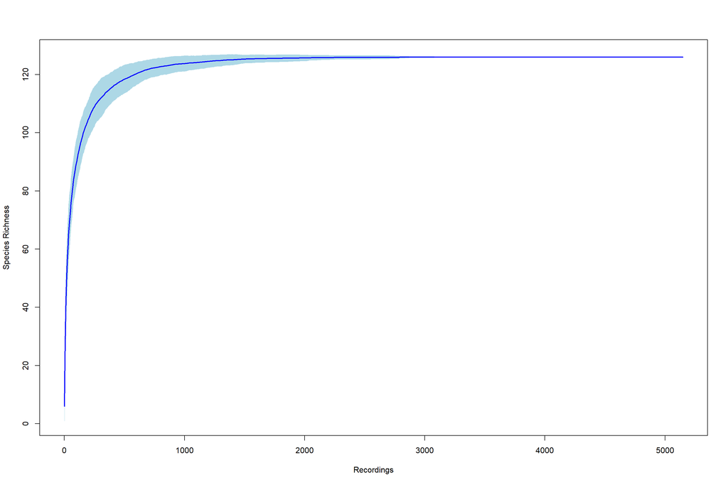

```r
spec_accum <- specaccum(comm_pa_filt, method = "random")

plot(spec_accum, ci.type = "poly", col = "blue", lwd = 2,
     ci.lty = 0, ci.col = "lightblue",
     xlab = "Recordings", ylab = "Species Richness")
```

```r
# now i want to run it on individual species, since this is a community approach. So we get to full richness, but how long should you record for SALS? or others? Also, I want to take into account that for BLRA, a full season of monitoring would be still appropriate
```

Still need to think about and contend with the fact that these are across multiple sites. Should I restrict to one site first? Adapt the code and note when a decision is made.

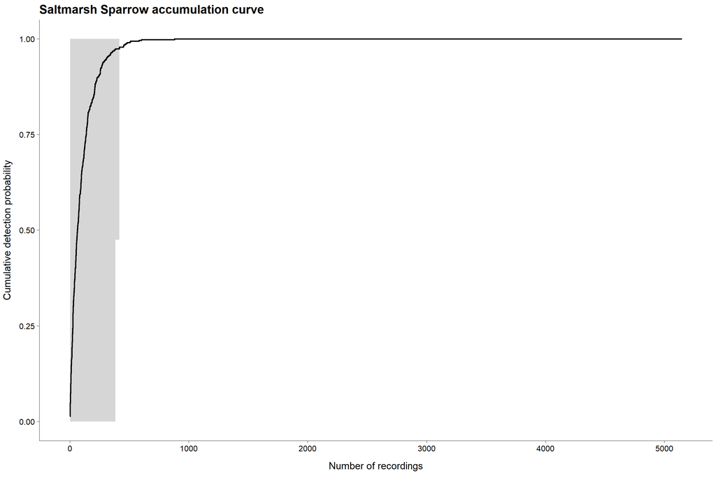

```r
# Chosen species to be changed in the YAML
species_code <- cfg$params$focal_species_birdNET

# Extract presence vector - literally a matrix of just that one species selected above
sp_vec <- as.integer(comm_pa_filt[[species_code]])  # 0/1 values per recording
n_samples <- length(sp_vec)
stopifnot(n_samples > 1)

# Randomize recording order many times
set.seed(123)
n_perm <- 500

accum_mat <- replicate(n_perm, {
  ord <- sample(sp_vec, size = n_samples, replace = FALSE)
  as.integer(cumsum(ord) > 0)   # 0 until first detection, then 1 thereafter
})

#Summarise mean + 95% interval across permutations
acc_df <- tibble(
  recordings = 1:n_samples,
  mean = rowMeans(accum_mat),
  lo = apply(accum_mat, 1, quantile, probs = 0.025),
  hi = apply(accum_mat, 1, quantile, probs = 0.975))

ggplot(acc_df, aes(recordings, mean)) +
  geom_ribbon(aes(ymin = lo, ymax = hi), alpha = 0.2) +
  geom_step(linewidth = 1) +
  scale_y_continuous(limits = c(0, 1)) +
  labs(
    title = paste0(species_code, " accumulation curve"),
    x = "Number of recordings",
    y = "Cumulative detection probability"
  ) +
  theme_publish(base_size= 15)
```

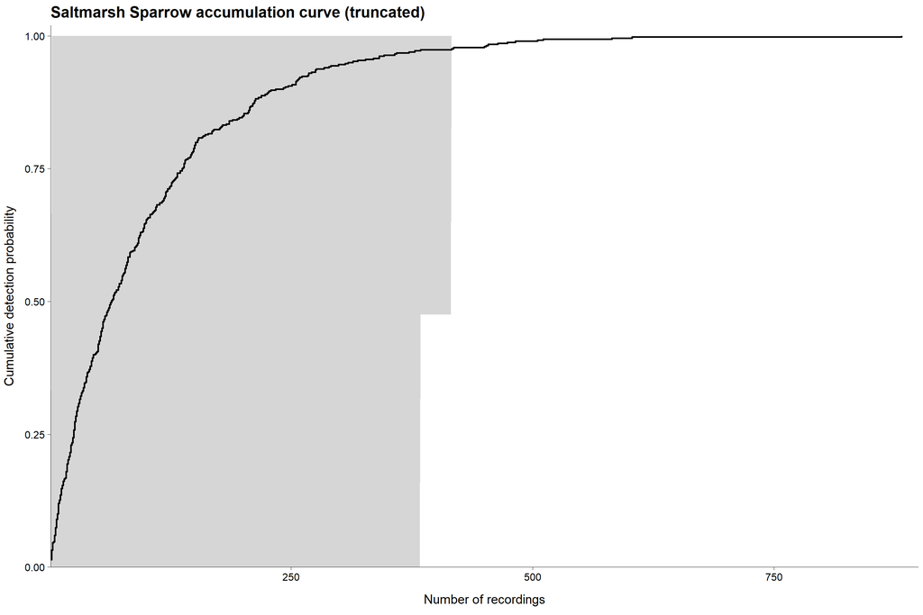

```r
# Find first recording where mean detection probability == 1
cutoff_n <- acc_df %>%
  dplyr::filter(mean >= 1) %>%
  dplyr::slice(1) %>%
  dplyr::pull(recordings)

if (length(cutoff_n) == 0) {
  cutoff_n <- max(acc_df$recordings)
}

acc_df_trunc <- acc_df %>%
  dplyr::filter(recordings <= cutoff_n)

ggplot(acc_df_trunc, aes(recordings, mean)) +
  geom_ribbon(aes(ymin = lo, ymax = hi), alpha = 0.2) +
  geom_step(linewidth = 1) +
  scale_y_continuous(limits = c(0, 1), expand = expansion(mult = c(0, 0.02))) +
  scale_x_continuous(expand = expansion(mult = c(0, 0.02))) +
  labs(
    title = glue("{species_code} accumulation curve (truncated)"),
    x = "Number of recordings",
    y = "Cumulative detection probability"
  ) +
  theme_publish(base_size = 15)
```